# HW4

Pin-wei, Yu

3/26/2020

# Normal Distribution

Given that correlation of variable = 0.5 , variance = 1 , mean = 0.

We know that the covariance of variable = 0.5

Thus, we generate the lower triangular Matrix C via Choleski Decompostitoin.

```r
A = diag(1,3,3)
B = diag(-.5,3,3) + 0.5
C<-t(chol(A + B))
```

Generate the 3*10000 zero-matrix X.

U1&U2 follow uniform(0,1)

Generate the 3*10000 Z-matrix which elements follow N(0,1)

Multiply the matrix C & Z, then replace the X matrix.

```r
X<- matrix(0,3,10000)
U1 <- runif(30000,0,1)
U2 <- runif(30000,0,1)
z<- sqrt(-2*log(U1))*cos(2*pi*U2)
Z<-matrix(z,3,10000)
X<-C%*%Z
```

Check the mean, variance and correlation of 10000 samples.

```
## Mean are:  0.006210055 0.02081188 0.01111955
```

```
## variance are:  1.002196 1.020489 0.9721822
```

```
## correlation of X1, X2 is:  0.4913267
```

```
## correlation of X2, X3 is:  0.4941975
```

```
## correlation of X1, X3 is:  0.4841827
```

# Copula

The marginaldistribution follow exp(1),and the copula is same as the last part.

In this part, we use Gaussian Copula.

First, we inverse the cdf of exp(1).

Second, with the copula above, we get the target distribution Y.

```r
F_x_inverse = function(y){
  return(-log(1-y))
}
XX<-pnorm(X)
Y=F_x_inverse(XX)
```

Plot the scattered Y1 &Y2.

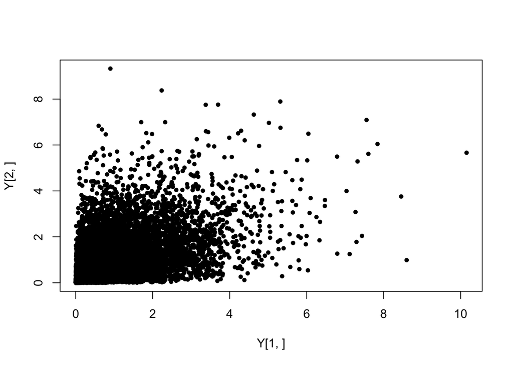

```r
plot(Y[1,],Y[2,],pch = 20)
```

In 3-dimention, plot the three scattered variables.

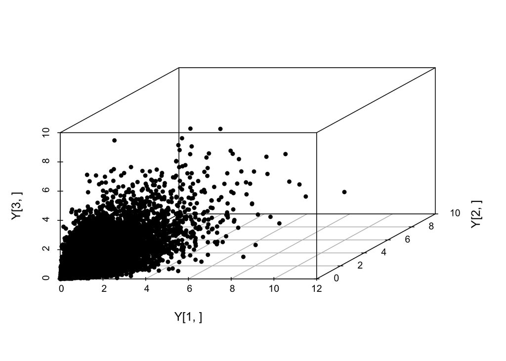

```r
library(scatterplot3d)
scatterplot3d(Y[1,],Y[2,],Y[3,], pch = 20)
```

Plot the ranked Y1 & Y2 with the adjusted proportion.

In this rank scattered gragh, the correlation between Y1 & Y2 is changing with variables.

When the rank are small or large, the correlation is quite high, while at the median-rank, the correlation is relatively low.

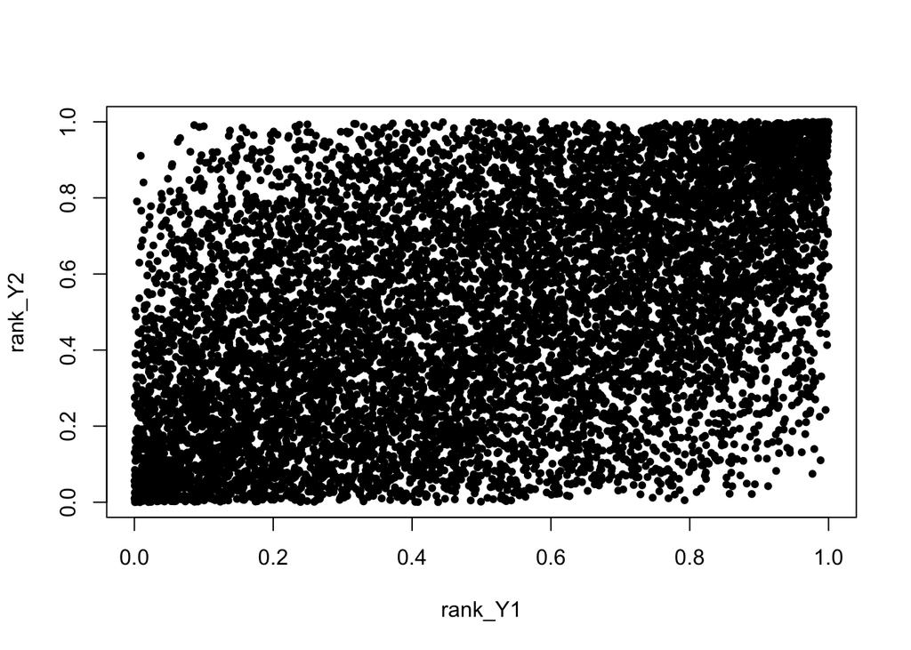

```r
rank_Y1 = rank(Y[1,])/10000
rank_Y2 = rank(Y[2,])/10000
plot(rank_Y1,rank_Y2, pch=20)
```